# Comparitive study on Machine learning Regression Models

José Pinto, Mariana Monteiro, Nirbhaya Shaji, Nuno Costa

24/05/2020

## Introduction

Modeling sequences is an advantageous feature in some ANN architectures, as there are plenty applications for sequence modeling, one of them being, for example, Speech Generation or Image Caption Generation. Sequences can appear in many forms, but what these all have in common is that each sequence can be seen as a series of data points. In this work, we will use XML-like strings as our sequences.

## Goals

The main goal of this work is to be able to study some properties of a few ANN architectures, namely MLP, RNN’s and LSTM’s. To do this, we will generate increasingly complex data and try to predict the last character of a subsequence of k characters.

## Dataset

```r
library(keras)
library(magrittr)
#keras::use_condaenv("r-tensorflow", required = TRUE)
#install_keras(method = "conda")
```

Below we have the xml like string generator function provided by the professor.

```r
gen_tag <- function(maxtaglen=5, all_letters=1) {
  taglen<-floor(runif(1)*maxtaglen+1)
  paste(letters[sample(1:(length(letters)*all_letters),taglen,replace=TRUE)], collapse='')
}
gen_line <- function(depth=5,...) {
  inner <- ""
  size <- runif(1)*7+3
  tag<-gen_tag(...)
  inner<-""
  while(runif(1)>0.4 && depth>0)
    if(inner=="")
      inner<-gen_line(depth=depth-1,...)
    else
      inner<-paste(inner,gen_line(depth=depth-1,...))
  endtag<-paste("<",tag,collapse='',sep='')
  if(inner=="")
    paste(tag,endtag)
  else
    paste(tag,inner,endtag)
}
# this function generates full sequences. You can truncate them using indexes.
gen_xml_data <- function(len=1000,...)
sapply(1:len,function(i) gen_line(...))
```

We use said function to create three datasets, a simple one, a normal/medium one and an hard one.  
The simple dataset only uses “a” in the tags, with a maximum tag length of 1, and maximum nesting of also one.  
The normal dataset use a subset of all the letters, with a maximum tag length of 3 and nesting depth of 3.  
Finnaly, the hard dataset, uses all letters, with a naximum tag length of 5 and nesting depth of 4.

```r
simpleXml = gen_xml_data(len=2000, depth=1,maxtaglen=1,all_letters=0.05)
normalXml = gen_xml_data(len=2000, depth=3,maxtaglen=3,all_letters=0.3)
hardXml = gen_xml_data(len=2000, depth=4,maxtaglen=5,all_letters=1)
```

Below we show a sample of the raw datasets, which we will next transform to a more suitable form.

```r
print("Simple Xml data:")
```

```
## [1] "Simple Xml data:"
```

```r
print(head(simpleXml))
```

```
## [1] "a a <a <a"                "a a <a a <a a <a a <a <a"
## [3] "a <a"                     "a a <a a <a <a"
## [5] "a <a"                     "a a <a <a"
```

```r
print("Nomal Xml data:")
```

```
## [1] "Nomal Xml data:"
```

```r
print(head(normalXml))
```

```
## [1] "gag b <b eb <eb e b gb <gb <b <e gaa gb <gb aff ga <ga <aff c gb <gb <c <gaa b <b eab <eab afe fe eg <eg e <e cb <cb <fe ac <ac fa <fa <afe <gag"
## [2] "d b <b gae cdb de <de <cdb dc <dc cg e <e <cg d f <f g <g ge <ge e <e d <d da <da ddc <ddc bg <bg <d f <f f <f dee db <db feb <feb gdc <gdc ad <ad aad <aad ee <ee ag <ag aeb <aeb <dee g <g e a <a bbg <bbg ad <ad <e <gae <d"
## [3] "fde dfa <dfa b ae <ae dda cb <cb <dda <b <fde"
## [4] "da <da"
## [5] "g <g"
## [6] "d e <e <d"
```

```r
print("Hard Xml data:")
```

```
## [1] "Hard Xml data:"
```

```r
print(head(hardXml))
```

```
## [1] "yub dev gud <gud sbu <sbu xxjhj <xxjhj <dev prgn <prgn vh e fs <fs q <q quah fou <fou <quah wdgpd <wdgpd iwd jmo <jmo yev <yev i <i aan <aan vom <vom uqq <uqq vn <vn v <v <iwd zaj <zaj yr qblu <qblu <yr i <i <e fml <fml kiy <kiy ox tatbm <tatbm yjon <yjon <ox <vh <yub"
## [2] "j bma nz <nz q kkjw mzz <mzz jambh <jambh <kkjw jbrfq <jbrfq <q lklpi ccot <ccot uat hun <hun hjhli <hjhli pskv <pskv l <l <uat <lklpi yp <yp <bma sxf s <s myxad m <m <myxad qna igk <igk e <e s q <q <s yzcfh <yzcfh xfa k <k <xfa <qna psxu <psxu <sxf <j"
## [3] "kr <kr"
## [4] "zdqc <zdqc"
## [5] "pkrd n <n r iwail igyyp <igyyp <iwail hm oftct <oftct tfotz vpoa <vpoa g <g kclzk <kclzk ieinj <ieinj qcvq <qcvq <tfotz <hm <r uxclu i <i nhk <nhk rxzlw m wyq <wyq <m ws qqxu <qqxu ukywo <ukywo arnc <arnc gtokx <gtokx <ws <rxzlw fe <fe dviug qf ituu <ituu b <b <qf ucdkk j <j <ucdkk <dviug fd…
## [6] "ey r w <w smv i <i zluy j <j um <um rngbi <rngbi <zluy nr zhp <zhp c <c f <f <nr <smv zkhvh oufmj tknxu <tknxu ipj <ipj <oufmj <zkhvh <r xfczt aodi bnb vj <vj l <l u <u gw <gw n <n <bnb fb vut <vut <fb s d <d <s qmzn fooi <fooi df <df <qmzn <aodi <xfczt iw ed <ed no <no <iw lbvx <lbvx ymsu f…
```

## Pre-processing

The first thing we are going to do is to transform our strings into an array of numbers, where each number is a unique identifier of a character of the string.  
Below we show the function to perform such operation.

```r
# turn a string into an array of encoded integers
labelEncoder = function(string, levels=NULL){
  # if possible characters not provided set default, all letters + space + "<"
  if(is.null(levels)){
    levels = c(letters," ","<")
  }
  # split string into its characters
  stringArray = strsplit(string,'')[[1]]
  # change characters into numeric factors
  encodedString = as.numeric(factor(stringArray,levels = levels))
  # shift factors to start at 0 (instead of 1)
  shiftedEncoding = encodedString - 1
  return(shiftedEncoding)
}

# label encodes all strings in one array
arrayLabelEncoder = function(arr, levels=NULL){
  encodedArray = c()
  for(string in arr){
    encodedArray = c(encodedArray, list(labelEncoder(string, levels)))
  }
  return(encodedArray)
}
```

Now we will pply the function to all our datasets.

```r
# '_' used for padding
vocab = c(letters," ","<","_")
simpleXmlEncoded = arrayLabelEncoder(simpleXml, vocab)
normalXmlEncoded = arrayLabelEncoder(normalXml, vocab)
hardXmlEncoded = arrayLabelEncoder(hardXml, vocab)
```

Below we can se a sample for the obtained results of this encoding.

```r
print("Simple Xml data:")
```

```
## [1] "Simple Xml data:"
```

```r
print(head(simpleXmlEncoded))
```

```
## [[1]]
## [1]  0 26  0 26 27  0 26 27  0
##
## [[2]]
##  [1]  0 26  0 26 27  0 26  0 26 27  0 26  0 26 27  0 26  0 26 27  0 26 27  0
##
## [[3]]
## [1]  0 26 27  0
##
## [[4]]
##  [1]  0 26  0 26 27  0 26  0 26 27  0 26 27  0
##
## [[5]]
## [1]  0 26 27  0
##
## [[6]]
## [1]  0 26  0 26 27  0 26 27  0
```

```r
print("Nomal Xml data:")
```

```
## [1] "Nomal Xml data:"
```

```r
print(head(normalXmlEncoded))
```

```
## [[1]]
##   [1]  6  0  6 26  1 26 27  1 26  4  1 26 27  4  1 26  4 26  1 26  6  1 26 27  6
##  [26]  1 26 27  1 26 27  4 26  6  0  0 26  6  1 26 27  6  1 26  0  5  5 26  6  0
##  [51] 26 27  6  0 26 27  0  5  5 26  2 26  6  1 26 27  6  1 26 27  2 26 27  6  0
##  [76]  0 26  1 26 27  1 26  4  0  1 26 27  4  0  1 26  0  5  4 26  5  4 26  4  6
## [101] 26 27  4  6 26  4 26 27  4 26  2  1 26 27  2  1 26 27  5  4 26  0  2 26 27
## [126]  0  2 26  5  0 26 27  5  0 26 27  0  5  4 26 27  6  0  6
##
## [[2]]
##   [1]  3 26  1 26 27  1 26  6  0  4 26  2  3  1 26  3  4 26 27  3  4 26 27  2  3
##  [26]  1 26  3  2 26 27  3  2 26  2  6 26  4 26 27  4 26 27  2  6 26  3 26  5 26
##  [51] 27  5 26  6 26 27  6 26  6  4 26 27  6  4 26  4 26 27  4 26  3 26 27  3 26
##  [76]  3  0 26 27  3  0 26  3  3  2 26 27  3  3  2 26  1  6 26 27  1  6 26 27  3
## [101] 26  5 26 27  5 26  5 26 27  5 26  3  4  4 26  3  1 26 27  3  1 26  5  4  1
## [126] 26 27  5  4  1 26  6  3  2 26 27  6  3  2 26  0  3 26 27  0  3 26  0  0  3
## [151] 26 27  0  0  3 26  4  4 26 27  4  4 26  0  6 26 27  0  6 26  0  4  1 26 27
## [176]  0  4  1 26 27  3  4  4 26  6 26 27  6 26  4 26  0 26 27  0 26  1  1  6 26
## [201] 27  1  1  6 26  0  3 26 27  0  3 26 27  4 26 27  6  0  4 26 27  3
##
## [[3]]
##  [1]  5  3  4 26  3  5  0 26 27  3  5  0 26  1 26  0  4 26 27  0  4 26  3  3  0
## [26] 26  2  1 26 27  2  1 26 27  3  3  0 26 27  1 26 27  5  3  4
##
## [[4]]
## [1]  3  0 26 27  3  0
##
## [[5]]
## [1]  6 26 27  6
##
## [[6]]
## [1]  3 26  4 26 27  4 26 27  3
```

```r
print("Hard Xml data:")
```

```
## [1] "Hard Xml data:"
```

```r
print(head(hardXmlEncoded))
```

```
## [[1]]
##   [1] 24 20  1 26  3  4 21 26  6 20  3 26 27  6 20  3 26 18  1 20 26 27 18  1 20
##  [26] 26 23 23  9  7  9 26 27 23 23  9  7  9 26 27  3  4 21 26 15 17  6 13 26 27
##  [51] 15 17  6 13 26 21  7 26  4 26  5 18 26 27  5 18 26 16 26 27 16 26 16 20  0
##  [76]  7 26  5 14 20 26 27  5 14 20 26 27 16 20  0  7 26 22  3  6 15  3 26 27 22
## [101]  3  6 15  3 26  8 22  3 26  9 12 14 26 27  9 12 14 26 24  4 21 26 27 24  4
## [126] 21 26  8 26 27  8 26  0  0 13 26 27  0  0 13 26 21 14 12 26 27 21 14 12 26
## [151] 20 16 16 26 27 20 16 16 26 21 13 26 27 21 13 26 21 26 27 21 26 27  8 22  3
## [176] 26 25  0  9 26 27 25  0  9 26 24 17 26 16  1 11 20 26 27 16  1 11 20 26 27
## [201] 24 17 26  8 26 27  8 26 27  4 26  5 12 11 26 27  5 12 11 26 10  8 24 26 27
## [226] 10  8 24 26 14 23 26 19  0 19  1 12 26 27 19  0 19  1 12 26 24  9 14 13 26
## [251] 27 24  9 14 13 26 27 14 23 26 27 21  7 26 27 24 20  1
##
## [[2]]
##   [1]  9 26  1 12  0 26 13 25 26 27 13 25 26 16 26 10 10  9 22 26 12 25 25 26 27
```

[output cut: 81 more lines]

Now that our dataset has the intended values and a more workable format (string) we will proceed to split the datasets into train, validation and test. For a total of 9 different data objects.  
As all found funtcions lacked some of the indended functionality, we created our own, presented below, to perform the operation.

```r
# split the data into n variable size partitions without overlap
# partitions represent proportion of data after first
# example, for a train 70%, validation 5%, test 25% - partition = c(0.05,0.25)
dataSplit = function(data, partitions = c(0.3)){
  # check if partitions are valid
  if(sum(partitions)>1){
    print("Total size of partitions greater than one. Aborting")
    return()
  }
  remainingData = data
  sets = c()
  # obtain data ofr each partition
  for(partition in partitions){
    partitionSize = floor(partition * length(data))
    partitionIndex = sample(seq_len(length(data)), size = partitionSize)
    sets = c(sets, list(data[partitionIndex]))
    remainingData = data[-partitionIndex]
  }

  # add remaining data to the top of the list (train data, for example)
  sets =  c(list(remainingData), sets)
  return(sets)
}
```

And here, we use the function to perform the split.

```r
# split simple XML data
simpleXmlTrain = dataSplit(simpleXmlEncoded, c(0.05,0.3))[[1]]
simpleXmlValidation = dataSplit(simpleXmlEncoded, c(0.05,0.3))[[2]]
simpleXmlTest = dataSplit(simpleXmlEncoded, c(0.05,0.3))[[3]]
# split normal XML data
normalXmlTrain = dataSplit(normalXmlEncoded, c(0.05,0.3))[[1]]
normalXmlValidation = dataSplit(normalXmlEncoded, c(0.05,0.3))[[2]]
normalXmlTest = dataSplit(normalXmlEncoded, c(0.05,0.3))[[3]]
# split hard XML data
hardXmlTrain = dataSplit(hardXmlEncoded, c(0.05,0.3))[[1]]
hardXmlValidation = dataSplit(hardXmlEncoded, c(0.05,0.3))[[2]]
hardXmlTest = dataSplit(hardXmlEncoded, c(0.05,0.3))[[3]]
```

```r
# turn a temporal dataset into a series of windows and targets
createWindow = function(data, windowSize, padding = TRUE, paddSimbol = 28){
  features = c()
  targets = c()
  # obtain windows for each example in data
  for(example in data){
    # padd the start of the example
    paddedExample = c(rep(paddSimbol, windowSize-1),example)
    window = c()
    target = c()
    for(i in 1:(length(example)-1)){
      # obtain a window
      window = rbind(window,paddedExample[i:(i+windowSize-1)])
      # obtain a target
      target = rbind(target,paddedExample[i+windowSize])
    }
    # save all windows and targets
    features = rbind(features, window)
    targets = rbind(targets, target)
  }
  return(list(features,targets))
}
```

For the y (target), the selected approach was to one hot encode it, to more easily allow verification.  
As the different datasets might contain different characters and we want the encoding to be consistent, we use the vocabulary (containing all letters, padding and other used simbols), to create the one hot encoding, forcing even if the character does not exist in the data, for the column to be created.

```r
# one hot encode column, with extra columns for possible values that do not show
one_hot = function(data,vocab){
  hotData = data.frame(data)
  for (char in 0:(length(vocab)-1)){
    hotData[paste("c",char,sep=".")] = ifelse(hotData[,1]==char,1,0)
  }
  hotData[,1]=NULL
  return(as.matrix(hotData))
}
```

We selected a window size of 4.  
We split the simple data.

```r
windowSize = 4
# split simple train data into X and Y
simpleXmlTrainX = createWindow(simpleXmlTest,windowSize)[[1]]
simpleXmlTrainY = one_hot(createWindow(simpleXmlTest,windowSize)[[2]],vocab)
# split simple validation data into X and Y
simpleXmlValidationX = createWindow(simpleXmlValidation,windowSize)[[1]]
simpleXmlValidationY = one_hot(createWindow(simpleXmlValidation,windowSize)[[2]],vocab)
# split simple test data into X and Y
simpleXmlTestX = createWindow(simpleXmlTest,windowSize)[[1]]
simpleXmlTestY = one_hot(createWindow(simpleXmlTest,windowSize)[[2]],vocab)
```

The normal data.

```r
# split normal train data into X and Y
normalXmlTrainX = createWindow(normalXmlTrain,windowSize)[[1]]
normalXmlTrainY = one_hot(createWindow(normalXmlTrain,windowSize)[[2]],vocab)
# split normal validation data into X and Y
normalXmlValidationX = createWindow(normalXmlValidation,windowSize)[[1]]
normalXmlValidationY = one_hot(createWindow(normalXmlValidation,windowSize)[[2]],vocab)
# split normal test data into X and Y
normalXmlTestX = createWindow(normalXmlTest,windowSize)[[1]]
normalXmlTestY = one_hot(createWindow(normalXmlTest,windowSize)[[2]],vocab)
```

And, the hard data.

```r
# split hard train data into X and Y
hardXmlTrainX = createWindow(hardXmlTrain,windowSize)[[1]]
hardXmlTrainY = one_hot(createWindow(hardXmlTrain,windowSize)[[2]],vocab)
# split hard validation data into X and Y
hardXmlValidationX = createWindow(hardXmlValidation,windowSize)[[1]]
hardXmlValidationY = one_hot(createWindow(hardXmlValidation,windowSize)[[2]],vocab)
# split hard test data into X and Y
hardXmlTestX = createWindow(hardXmlTest,windowSize)[[1]]
hardXmlTestY = one_hot(createWindow(hardXmlTest,windowSize)[[2]],vocab)
```

## Modeling

### MLP

#### Simple dataset

After some testing , we selected three hidden layers, with weights 32, 32, 16 respectively.  
As we are usig the one hot encoded target, we use classification loss and metric, with the last layer activation function being a sigmoid.

```r
# create MLP model
model <- keras_model_sequential()
  # set input layer
model %>%
    layer_dense(units = 32, input_shape = c(windowSize), activation = "relu") %>%
  # add hidden layers
    # size power of 2
    # activation function relu
    layer_dense(units = 32, activation = "relu") %>%
    layer_dense(units = 16, activation = "relu") %>%
  # add output layer
    # size = to vocab size
    # activation sigmoid for classification
    layer_dense(units = length(vocab), activation = "sigmoid") %>%

  # compile with error for classification and optimization algorithm
    compile(
    loss = 'binary_crossentropy',
    optimizer = optimizer_rmsprop(),
    metrics = c('accuracy')
  )
```

Then we trained the model until convergence, using the validation data to gauge the models performance on unseen data.

```r
# train MLP
fit_mlp <- model %>%
  fit(
    x = simpleXmlTrainX,
    y = simpleXmlTrainY,
    validation_data = list(simpleXmlValidationX,simpleXmlValidationY),
    epochs = 25,
    batch_size = 8,
  )

fit_mlp
```

```
## Trained on 6,765 samples (batch_size=8, epochs=25)
## Final epoch (plot to see history):
##         loss: 0.01081
##     accuracy: 0.9939
##     val_loss: 0.01111
## val_accuracy: 0.9934
```

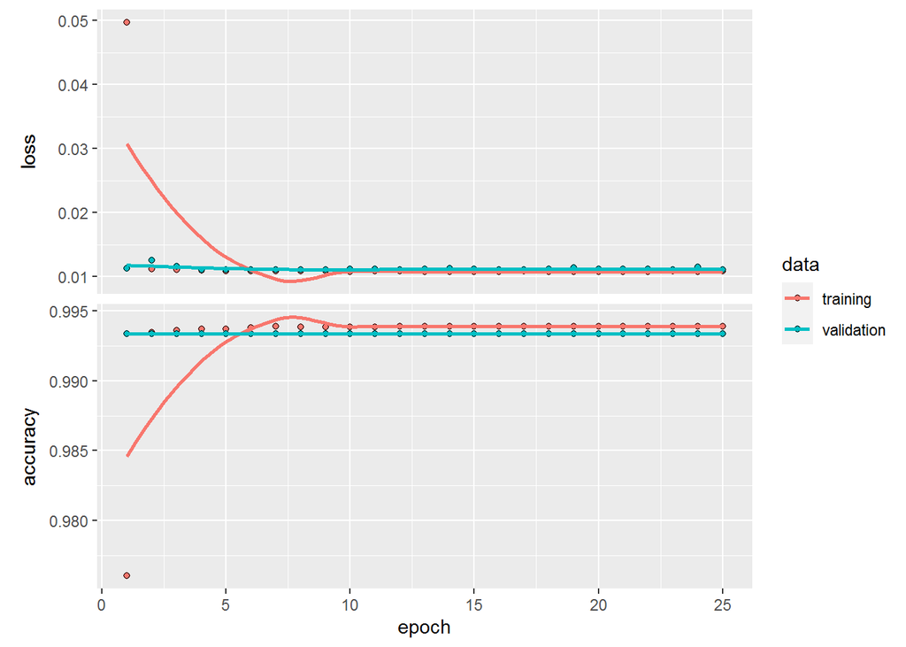

```r
plot(fit_mlp)
```

#### Normal dataset

After some testing , we selected two hidden layers, with weights 32, 16 respectively.  
As we are usig the one hot encoded target, we use classification loss and metric, with the last layer activation function being a sigmoid.

```r
# create MLP model
model <- keras_model_sequential()
  # set input layer
model %>%
    layer_dense(units = 32, input_shape = c(windowSize), activation = "relu") %>%
  # add hidden layers
    # size power of 2
    # activation function relu
    layer_dense(units = 16, activation = "relu") %>%
  # add output layer
    # size = to vocab size
    # activation sigmoid for classification
    layer_dense(units = length(vocab), activation = "sigmoid") %>%

  # compile with error for classification and optimization algorithm
    compile(
    loss = 'binary_crossentropy',
    optimizer = optimizer_rmsprop(),
    metrics = c('accuracy')
  )
```

Then we trained the model until convergence, using the validation data to gauge the models performance on unseen data.

```r
# train MLP
fit_mlp <- model %>%
  fit(
    x = normalXmlTrainX,
    y = normalXmlTrainY,
    validation_data = list(normalXmlValidationX,normalXmlValidationY),
    epochs = 10,
    batch_size = 8,
  )

fit_mlp
```

```
## Trained on 78,002 samples (batch_size=8, epochs=10)
## Final epoch (plot to see history):
##         loss: 0.08371
##     accuracy: 0.9695
##     val_loss: 0.08362
## val_accuracy: 0.9696
```

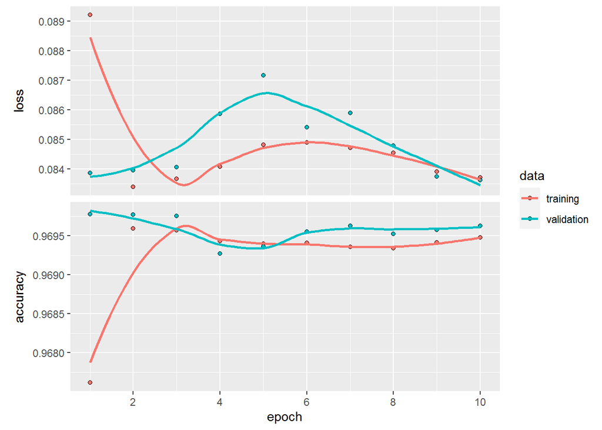

```r
plot(fit_mlp)
```